# DATS 6101 Project 2

# 5 Predicted Probability of Depression (Obesity × COVID Period)

Odds ratios are helpful, but predicted probabilities are often easier to interpret. We estimated predicted depression probabilities for four groups: 1) Non-obese, Pre-COVID 2) Obese, Pre-COVID 3) Non-obese, Post-COVID 4) Obese, Post-COVID

To isolate obesity and COVID effects, predictions were generated holding age_group and sex constant at a reference level (the first factor level in the dataset).

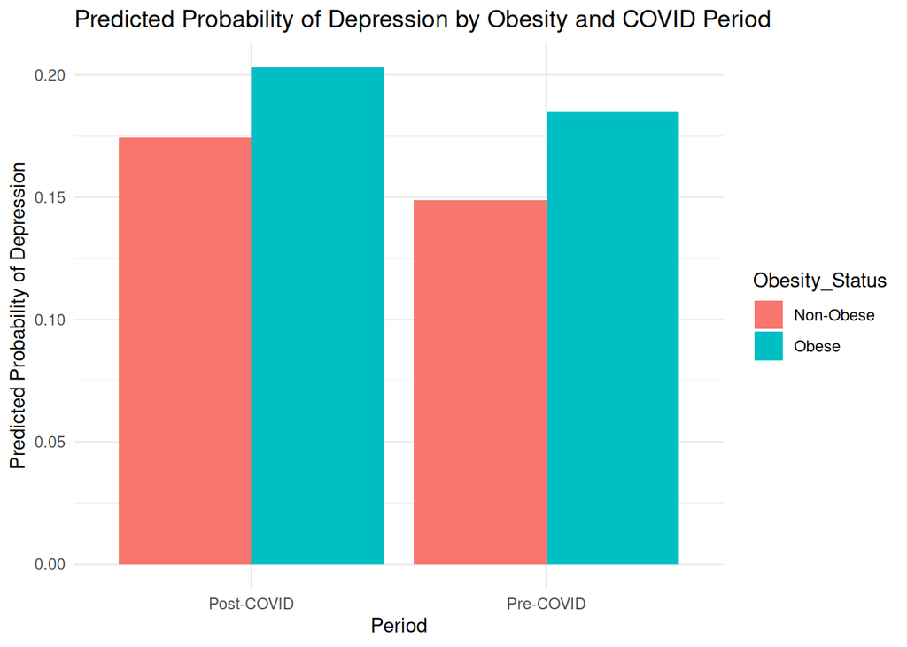

```r
pred_grid <- expand.grid(
obese = c(0, 1),
covid_period = c(0, 1),
age_group = levels(model_data$age_group)[1],
sex = levels(model_data$sex)[1]
)

pred_grid$pred_prob <- predict(
model_int_fixed,
newdata = pred_grid,
type = "response"
)

pred_grid <- pred_grid %>%
mutate(
Obesity_Status = if_else(obese == 1, "Obese", "Non-Obese"),
Period = if_else(covid_period == 1, "Post-COVID", "Pre-COVID")
)

ggplot(pred_grid, aes(x = Period, y = pred_prob, fill = Obesity_Status)) +
geom_bar(stat = "identity", position = "dodge") +
labs(
title = "Predicted Probability of Depression by Obesity and COVID Period",
x = "Period",
y = "Predicted Probability of Depression"
) +
theme_minimal()
```

**Interpretation:** If predicted depression probabilities rise in the post-COVID period for both obesity groups, that suggests overall depression risk increased after the pandemic. If the gap between obese and non-obese changes from pre to post, that indicates the relationship between obesity and depression shifted across periods.

### 5.0.1 Predicted Probability with 95% Confidence Intervals

Predicted Probability with 95% Confidence Intervals  
To quantify uncertainty, we computed 95% confidence intervals around predicted probabilities using standard errors on the log-odds scale and transforming back to probability.

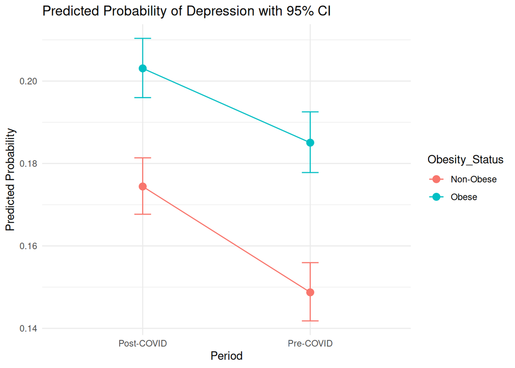

```r
pred_probs <- predict(model_int_fixed, newdata = pred_grid, type = "link", se.fit = TRUE)

pred_grid$fit <- plogis(pred_probs$fit)
pred_grid$lwr <- plogis(pred_probs$fit - 1.96 * pred_probs$se.fit)
pred_grid$upr <- plogis(pred_probs$fit + 1.96 * pred_probs$se.fit)

ggplot(pred_grid, aes(x = Period, y = fit, color = Obesity_Status)) +
geom_point(size = 3) +
geom_errorbar(aes(ymin = lwr, ymax = upr), width = 0.1) +
geom_line(aes(group = Obesity_Status)) +
labs(
title = "Predicted Probability of Depression with 95% CI",
y = "Predicted Probability"
) +
theme_minimal()
```

### 5.0.2 Critical Limitations

Self-Reported Outcome: Depression history is self-reported and may include reporting bias; it also does not measure severity.

Reference-Level Predictions: Predicted probabilities are computed at a fixed reference age_group and sex, so absolute probability values differ for other demographic profiles.

Omitted Variables: This model controls only for age group and sex; additional covariates (income, race/ethnicity, exercise, alcohol use, comorbidities) may further explain depression risk and change the estimated obesity effect.

### 5.0.3 Recommendations for Future Work

Expanded Controls: Add socioeconomic and behavioral covariates to test robustness of the obesity effect.

Subgroup Analysis: Fit the model separately by sex or age_group to check for heterogeneous effects.

Survey Design Considerations: If survey weights are available in the BRFSS file, incorporate them to improve population-level inference.